# Session 2: GDPUSAvar ARMA Modelling

Los datos provienen de la web oficial (http://www.bea.gov/national/index.htm) y corresponden a la variación porcentual respecto al periodo anterior del producto interior bruto de los Estados Unidos, basado en precios encadenados, desde el primer trimestre de 1990 hasta el último de 2017 (últimos 28 años). La serie está ajustada estacionalmente.

### Plot the time series GDPUSAvar

```r
(serie=ts((read.table("gdpUSAvar.dat",header=F)),start=1990,freq=4))
```

```
##      Qtr1 Qtr2 Qtr3 Qtr4
## 1990  4.5  1.6  0.1 -3.4
## 1991 -1.9  3.1  1.9  1.8
## 1992  4.8  4.5  3.9  4.1
## 1993  0.8  2.4  2.0  5.4
## 1994  4.0  5.6  2.4  4.6
## 1995  1.4  1.4  3.5  2.9
## 1996  2.7  7.2  3.7  4.3
## 1997  3.1  6.2  5.2  3.1
## 1998  4.0  3.9  5.3  6.7
## 1999  3.2  3.3  5.1  7.1
## 2000  1.2  7.8  0.5  2.3
## 2001 -1.1  2.1 -1.3  1.1
## 2002  3.7  2.2  2.0  0.3
## 2003  2.1  3.8  6.9  4.8
## 2004  2.3  3.0  3.7  3.5
## 2005  4.3  2.1  3.4  2.3
## 2006  4.9  1.2  0.4  3.2
## 2007  0.2  3.1  2.7  1.4
## 2008 -2.7  2.0 -1.9 -8.2
## 2009 -5.4 -0.5  1.3  3.9
## 2010  1.7  3.9  2.7  2.5
## 2011 -1.5  2.9  0.8  4.6
## 2012  2.7  1.9  0.5  0.1
## 2013  2.8  0.8  3.1  4.0
## 2014 -0.9  4.6  5.2  2.0
## 2015  3.2  2.7  1.6  0.5
## 2016  0.6  2.2  2.8  1.8
## 2017  1.2  3.1  3.2  2.6
```

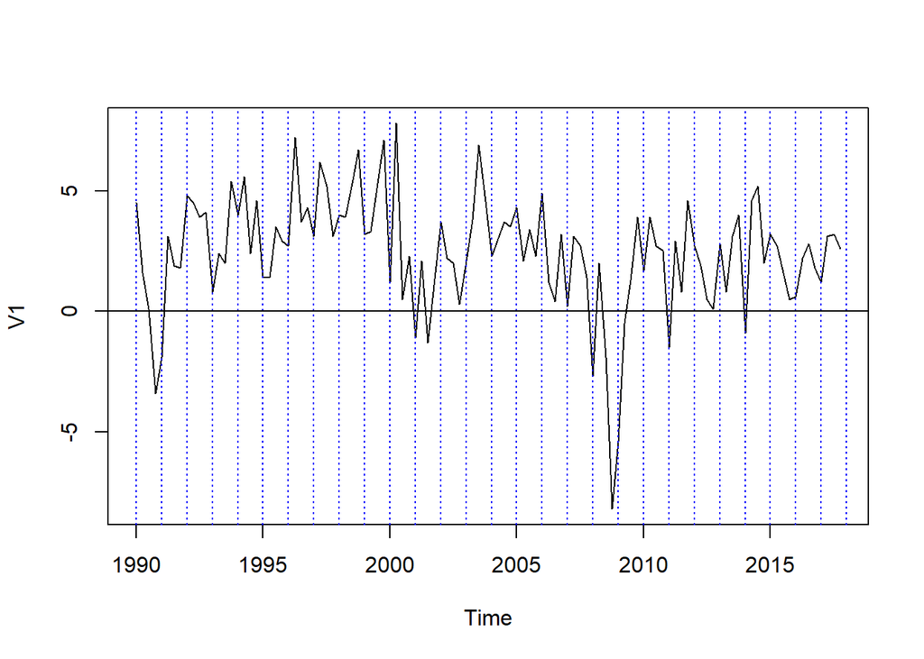

```r
plot(serie)
abline(v=1990:2018,col=4,lty=3)
abline(h=0)
```

```r
#abline(h=mean(serie),col=2)
```

1990: ?? 2008-2010: ??

## I. Model Identification

### Ia. Tranforming series to stationarity:

#### Is Variance constant?

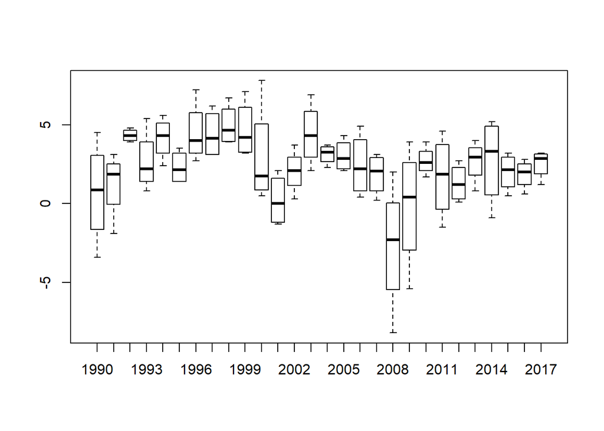

```r
boxplot(serie~floor(time(serie)))
```

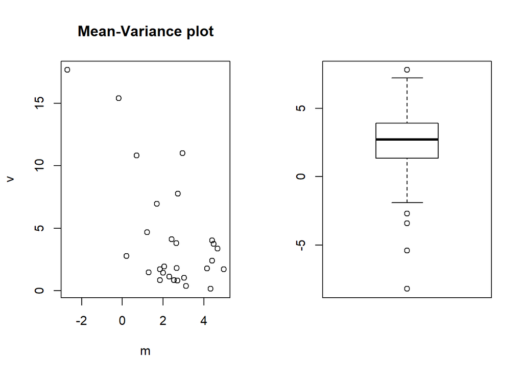

```r
#LA
par(mfrow=c(1,2))
m=apply(matrix(serie,ncol=28),2,mean)
v=apply(matrix(serie,ncol=28),2,var)
plot(v~m,main="Mean-Variance plot")
boxplot(serie)
```

```r
#abline(lm(v~m))
#summary(lm(v~m)): be aware of potential outliers
par(mfrow=c(1,1))
```

##### The varianza seemingly constant!

#### Is seasonality present? Nop, GDPUSAvar series has been Seasonally adjusted

#### Is the mean constant?

Plot again the whole time series

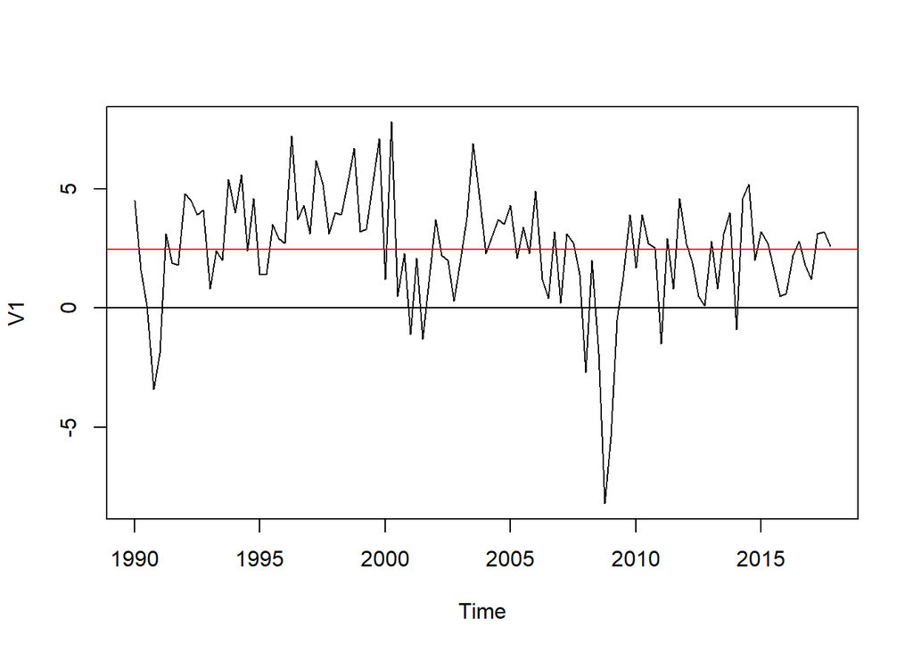

```r
plot(serie)
abline(h=0)
abline(h=mean(serie),col=2)
```

##### Constant mean, but different from zero!!!

#### Is an extra differentiation needed? NOP! Observe that the mean becomes zero but the variance increases…

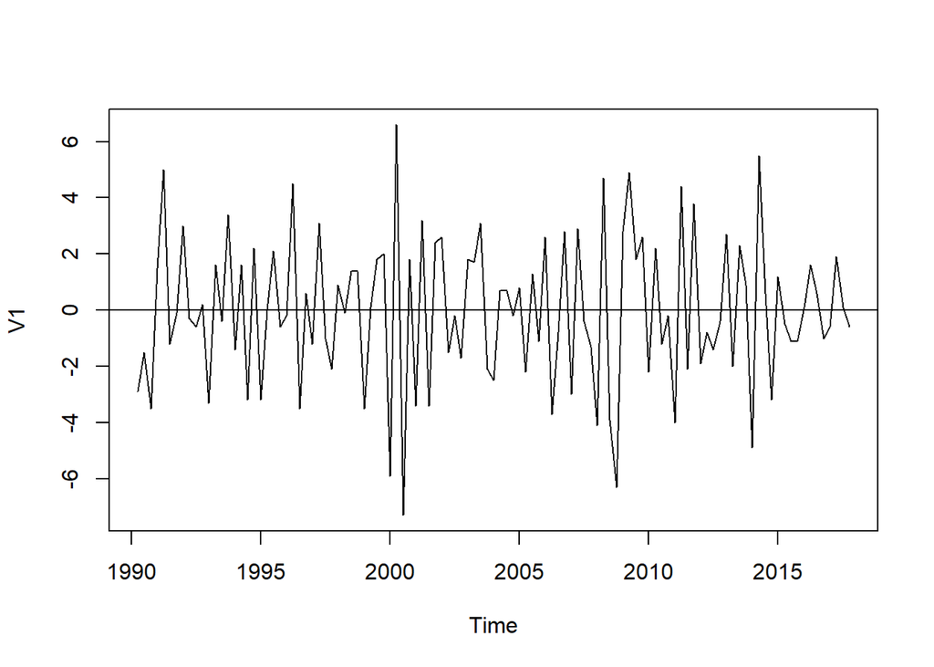

```r
d1serie=diff(serie)
plot(d1serie)
abline(h=0)
```

```r
var(serie)
```

```
##          V1
## V1 5.894402
```

```r
var(d1serie)
```

```
##          V1
## V1 6.967432
```

##### In this case, the given series GDPUSAvar shows no seasonality, has constant mean and variance. Its covariance structure does not depends on the time-origin. Notice that the ACF decays fast towards zero.

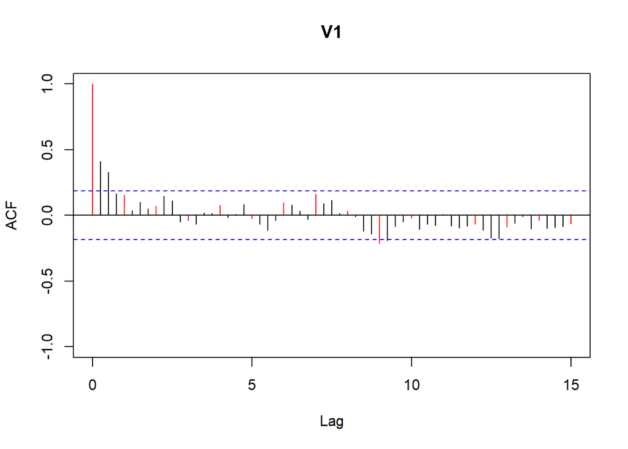

```r
acf(serie,ylim=c(-1,1),lag.max=60,col=c(2,rep(1,3)))
```

Thus, the GDPUSAvar time series is already stationary! Proceed to identify possible values of p and q of the ARMA(p,q) model by looking to P(ACF)

### Ib. Selection of plausible models to fit: propose >=2 models (principle of parsimony!)

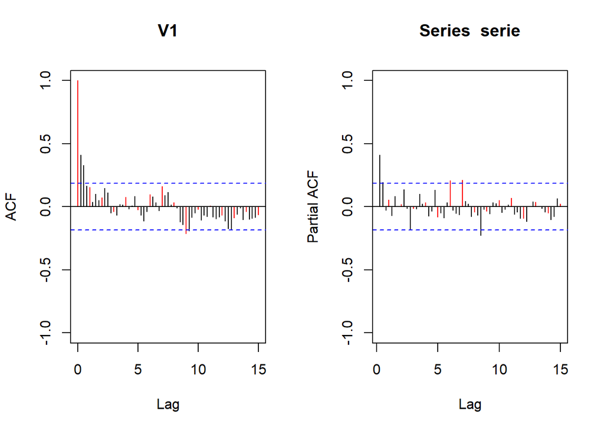

```r
par(mfrow=c(1,2))
acf(serie,ylim=c(-1,1),lag.max=60,col=c(2,rep(1,3)))
pacf(serie,ylim=c(-1,1),lag.max=60,col=c(rep(1,3),2))
```

```r
par(mfrow=c(1,1))
```

Three models proposed: AR(2), MA(2), ARMA(1,1)

### ‘Load’ the function ‘validation’: used later

```r
#################Validation#################################
validation=function(model,dades){
  s=frequency(get(model$series))
  resid=model$residuals
  par(mfrow=c(2,2),mar=c(3,3,3,3))
  #Residuals plot
  plot(resid,main="Residuals")
  abline(h=0)
  abline(h=c(-3*sd(resid),3*sd(resid)),lty=3,col=4)
  #Square Root of absolute values of residuals (Homocedasticity)
  scatter.smooth(sqrt(abs(resid)),main="Square Root of Absolute residuals",
                 lpars=list(col=2))

  #Normal plot of residuals
  qqnorm(resid)
  qqline(resid,col=2,lwd=2)

  ##Histogram of residuals with normal curve
  hist(resid,breaks=20,freq=F)
  curve(dnorm(x,mean=mean(resid),sd=sd(resid)),col=2,add=T)


  #ACF & PACF of residuals
  par(mfrow=c(1,2))
  acf(resid,ylim=c(-1,1),lag.max=60,col=c(2,rep(1,s-1)),lwd=1)
  pacf(resid,ylim=c(-1,1),lag.max=60,col=c(rep(1,s-1),2),lwd=1)
  par(mfrow=c(1,1))

  #ACF & PACF of square residuals
  par(mfrow=c(1,2))
  acf(resid^2,ylim=c(-1,1),lag.max=60,col=c(2,rep(1,s-1)),lwd=1)
  pacf(resid^2,ylim=c(-1,1),lag.max=60,col=c(rep(1,s-1),2),lwd=1)
  par(mfrow=c(1,1))

  #Ljung-Box p-values
  par(mar=c(2,2,1,1))
  tsdiag(model,gof.lag=7*s)
  cat("\n--------------------------------------------------------------------\n")
  print(model)

  #Stationary and Invertible
  cat("\nModul of AR Characteristic polynomial Roots: ",
      Mod(polyroot(c(1,-model$model$phi))),"\n")
  cat("\nModul of MA Characteristic polynomial Roots: ",
      Mod(polyroot(c(1,model$model$theta))),"\n")

  #Model expressed as an MA infinity (psi-weights)
  psis=ARMAtoMA(ar=model$model$phi,ma=model$model$theta,lag.max=36)
  names(psis)=paste("psi",1:36)
  cat("\nPsi-weights (MA(inf))\n")
  cat("\n--------------------\n")
  print(psis[1:20])

  #Model expressed as an AR infinity (pi-weights)
  pis=-ARMAtoMA(ar=-model$model$theta,ma=-model$model$phi,lag.max=36)
  names(pis)=paste("pi",1:36)
  cat("\nPi-weights (AR(inf))\n")
  cat("\n--------------------\n")
  print(pis[1:20])

  ##Shapiro-Wilks Normality test
  print(shapiro.test(resid(mod)))

  #Sample ACF vs. Teoric ACF
  par(mfrow=c(2,2),mar=c(3,3,3,3))
  acf(dades, ylim=c(-1,1) ,lag.max=36,main="Sample ACF")

  plot(ARMAacf(model$model$phi,model$model$theta,lag.max=36),ylim=c(-1,1),
       type="h",xlab="Lag",  ylab="", main="ACF Teoric")
  abline(h=0)

  #Sample PACF vs. Teoric PACF
  pacf(dades, ylim=c(-1,1) ,lag.max=36,main="Sample PACF")

  plot(ARMAacf(model$model$phi,model$model$theta,lag.max=36, pacf=T),ylim=c(-1,1),
       type="h", xlab="Lag", ylab="", main="PACF Teoric")
  abline(h=0)
  par(mfrow=c(1,1))
}
################# Fi Validació #################################
```

## II. Estimation Model 1: AR(2) process

```r
(mod=arima(serie,order=c(2,0,0) )) #by default ,include.mean=T
```

```
##
## Call:
## arima(x = serie, order = c(2, 0, 0))
##
## Coefficients:
##          ar1     ar2  intercept
##       0.3310  0.1884     2.4669
## s.e.  0.0926  0.0925     0.4196
##
## sigma^2 estimated as 4.672:  log likelihood = -245.38,  aic = 498.76
```

### Check significance of estimated parameters

Remember: ML estimators are asymptotically normally distributed. Use this result to check significance of the 3 estimated parameters.

```r
cat("Z values:",fill=TRUE)
```

```
## Z values:
```

```r
abs(mod$coef/sqrt(diag(mod$var.coef)))
```

```
##       ar1       ar2 intercept
##  3.575532  2.037744  5.879297
```

All significant since |coeff/SE_coeff| >2 or check 95%CI

### Check for stationarity of the fitted model

Write the characteristic polynomial of the fitted AR(2) model: compute module/roots (must be outside unit circle)

Recall: AR(p) models are known to be invertible, but stationarity must be checked.This is done inside the validation function…

## III. Validation Model 1: AR(2) process

AR(2) process validation: several diagnostic tools used #library(moments)

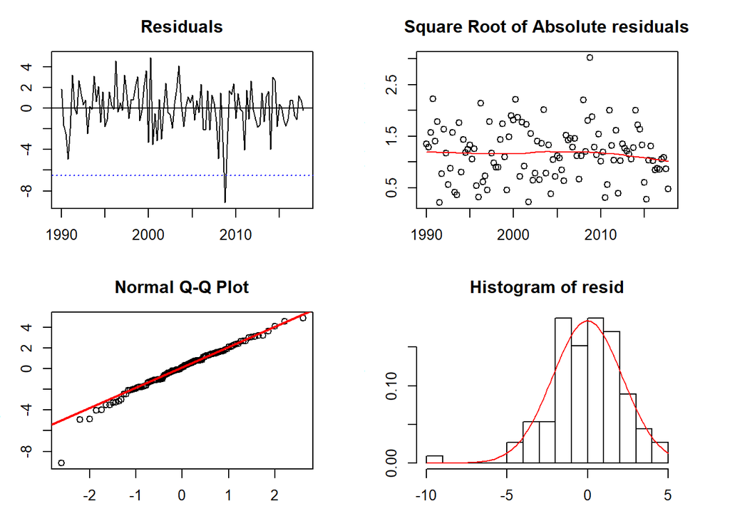

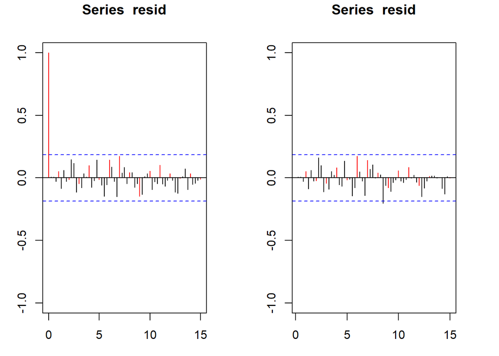

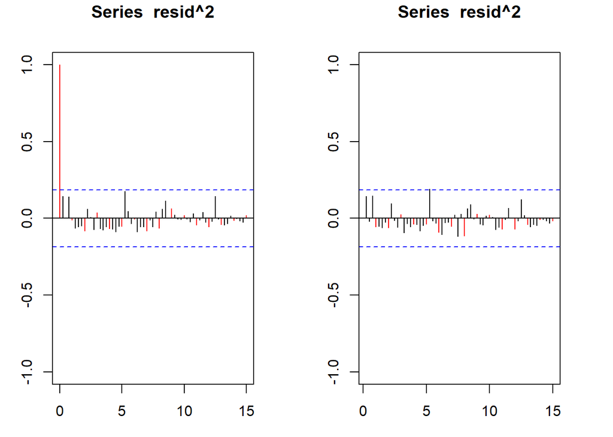

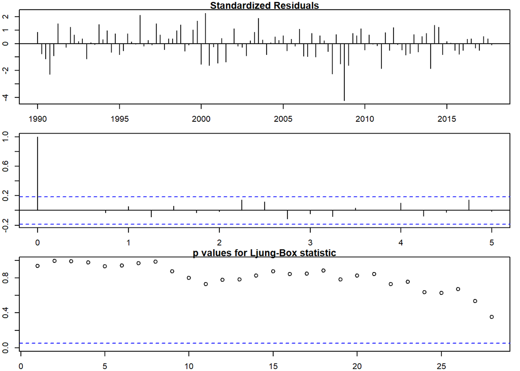

```
##
## --------------------------------------------------------------------
##
## Call:
## arima(x = serie, order = c(2, 0, 0))
##
## Coefficients:
##          ar1     ar2  intercept
##       0.3310  0.1884     2.4669
## s.e.  0.0926  0.0925     0.4196
##
## sigma^2 estimated as 4.672:  log likelihood = -245.38,  aic = 498.76
##
## Modul of AR Characteristic polynomial Roots:  1.587223 3.344238
##
## Modul of MA Characteristic polynomial Roots:
##
## Psi-weights (MA(inf))
##
## --------------------
##        psi 1        psi 2        psi 3        psi 4        psi 5
## 0.3310095462 0.2979603935 0.1609876405 0.1094221202 0.0665487228
##        psi 6        psi 7        psi 8        psi 9       psi 10
## 0.0426426321 0.0266524367 0.0168557875 0.0106005611 0.0066844005
##       psi 11       psi 12       psi 13       psi 14       psi 15
## 0.0042096727 0.0026527366 0.0016711543 0.0010529252 0.0006633622
##       psi 16       psi 17       psi 18       psi 19       psi 20
## 0.0004179430 0.0002633160 0.0001658977 0.0001045206 0.0000658513
##
## Pi-weights (AR(inf))
##
## --------------------
##      pi 1      pi 2      pi 3      pi 4      pi 5      pi 6      pi 7
## 0.3310095 0.1883931 0.0000000 0.0000000 0.0000000 0.0000000 0.0000000
##      pi 8      pi 9     pi 10     pi 11     pi 12     pi 13     pi 14
## 0.0000000 0.0000000 0.0000000 0.0000000 0.0000000 0.0000000 0.0000000
##     pi 15     pi 16     pi 17     pi 18     pi 19     pi 20
## 0.0000000 0.0000000 0.0000000 0.0000000 0.0000000 0.0000000
##
##  Shapiro-Wilk normality test
##
## data:  resid(mod)
## W = 0.97149, p-value = 0.0169
```

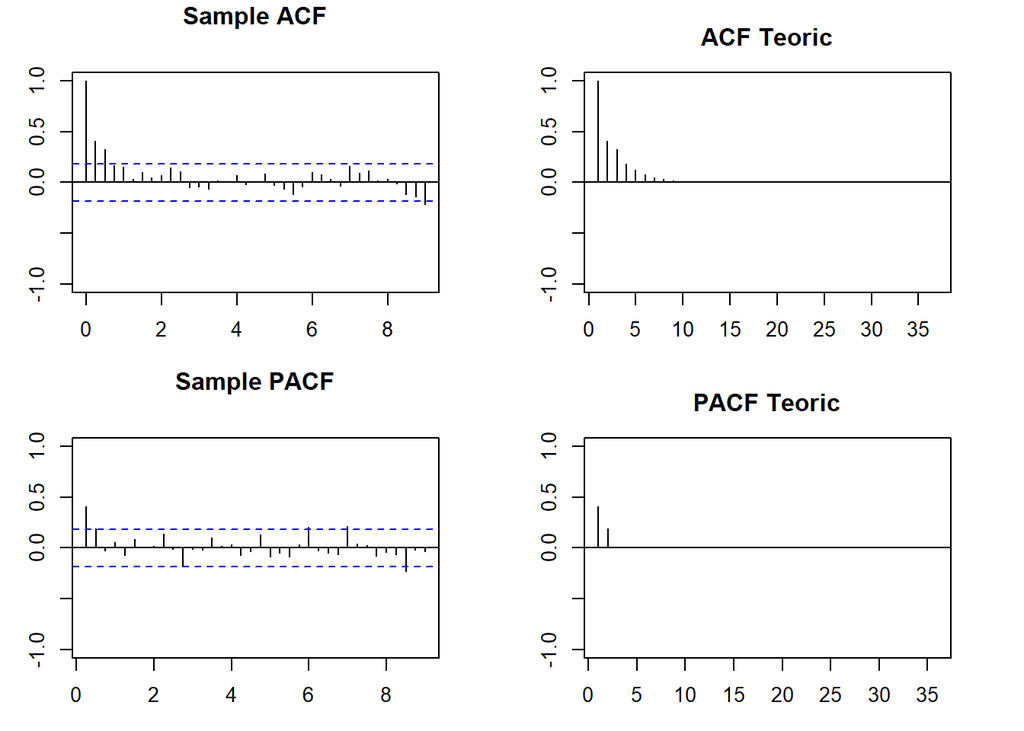

```r
dades=serie
model=mod
validation(model,dades)
```

### Conclusions: The asumptions are reasonably fulfilled, but be aware of possible outliers (study them!)

### Model 2: MA(2)

```r
(mod=arima(serie,order=c(0,0,2)))
```

```
##
## Call:
## arima(x = serie, order = c(0, 0, 2))
##
## Coefficients:
##          ma1     ma2  intercept
##       0.3287  0.2392     2.4561
## s.e.  0.0941  0.0796     0.3227
##
## sigma^2 estimated as 4.788:  log likelihood = -246.72,  aic = 501.45
```

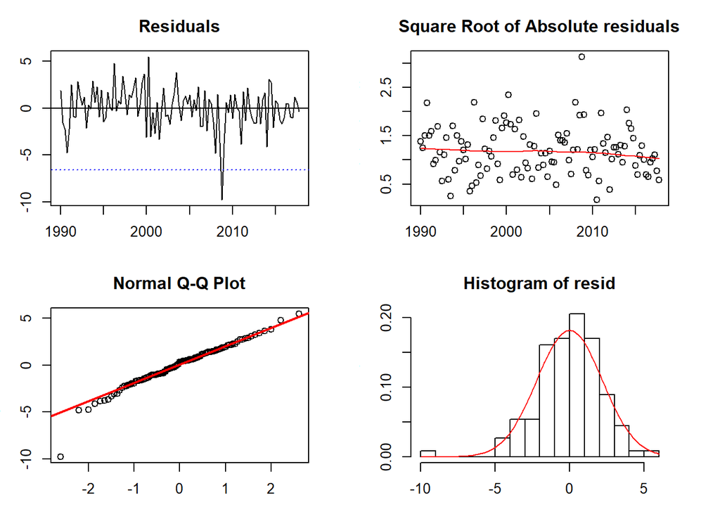

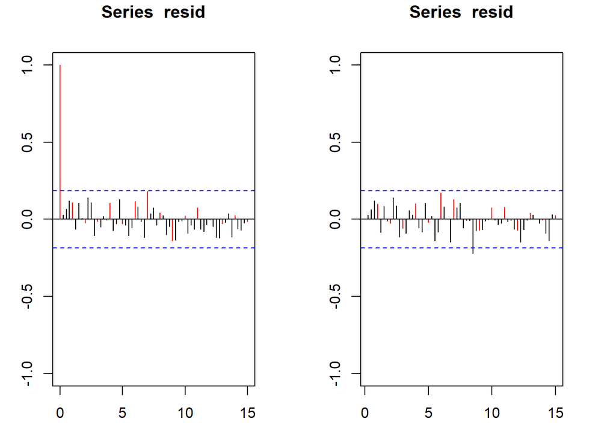

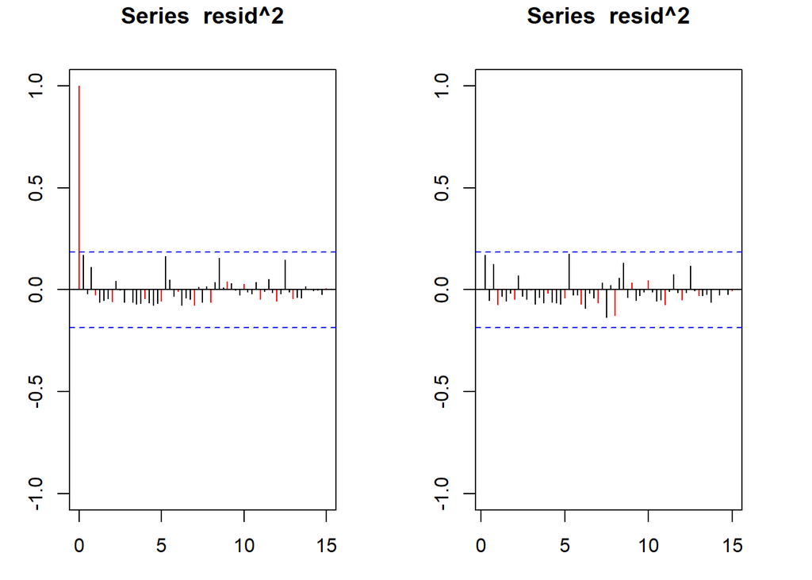

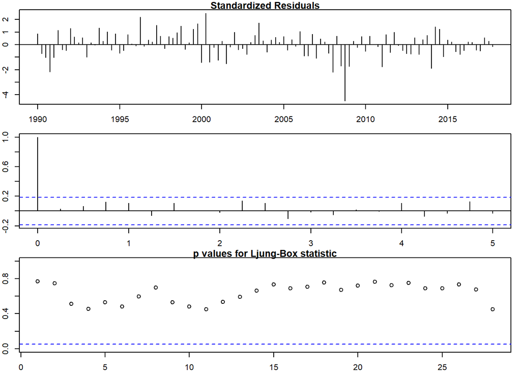

```
##
## --------------------------------------------------------------------
##
## Call:
## arima(x = serie, order = c(0, 0, 2))
##
## Coefficients:
##          ma1     ma2  intercept
##       0.3287  0.2392     2.4561
## s.e.  0.0941  0.0796     0.3227
##
## sigma^2 estimated as 4.788:  log likelihood = -246.72,  aic = 501.45
##
## Modul of AR Characteristic polynomial Roots:
##
## Modul of MA Characteristic polynomial Roots:  2.04458 2.04458
##
## Psi-weights (MA(inf))
##
## --------------------
##     psi 1     psi 2     psi 3     psi 4     psi 5     psi 6     psi 7
## 0.3286748 0.2392168 0.0000000 0.0000000 0.0000000 0.0000000 0.0000000
##     psi 8     psi 9    psi 10    psi 11    psi 12    psi 13    psi 14
## 0.0000000 0.0000000 0.0000000 0.0000000 0.0000000 0.0000000 0.0000000
##    psi 15    psi 16    psi 17    psi 18    psi 19    psi 20
## 0.0000000 0.0000000 0.0000000 0.0000000 0.0000000 0.0000000
##
## Pi-weights (AR(inf))
##
## --------------------
##          pi 1          pi 2          pi 3          pi 4          pi 5
##  3.286748e-01  1.311897e-01 -1.217433e-01  8.631183e-03  2.628619e-02
##          pi 6          pi 7          pi 8          pi 9         pi 10
## -1.070434e-02 -2.769854e-03  3.471039e-03 -4.782473e-04 -6.731430e-04
##         pi 11         pi 12         pi 13         pi 14         pi 15
##  3.356500e-04  5.070742e-05 -9.695938e-05  1.973804e-05  1.670692e-05
##         pi 16         pi 17         pi 18         pi 19         pi 20
## -1.021281e-05 -6.398805e-07  2.653390e-06 -7.190323e-07 -3.984077e-07
##
##  Shapiro-Wilk normality test
##
## data:  resid(mod)
## W = 0.96449, p-value = 0.004486
```

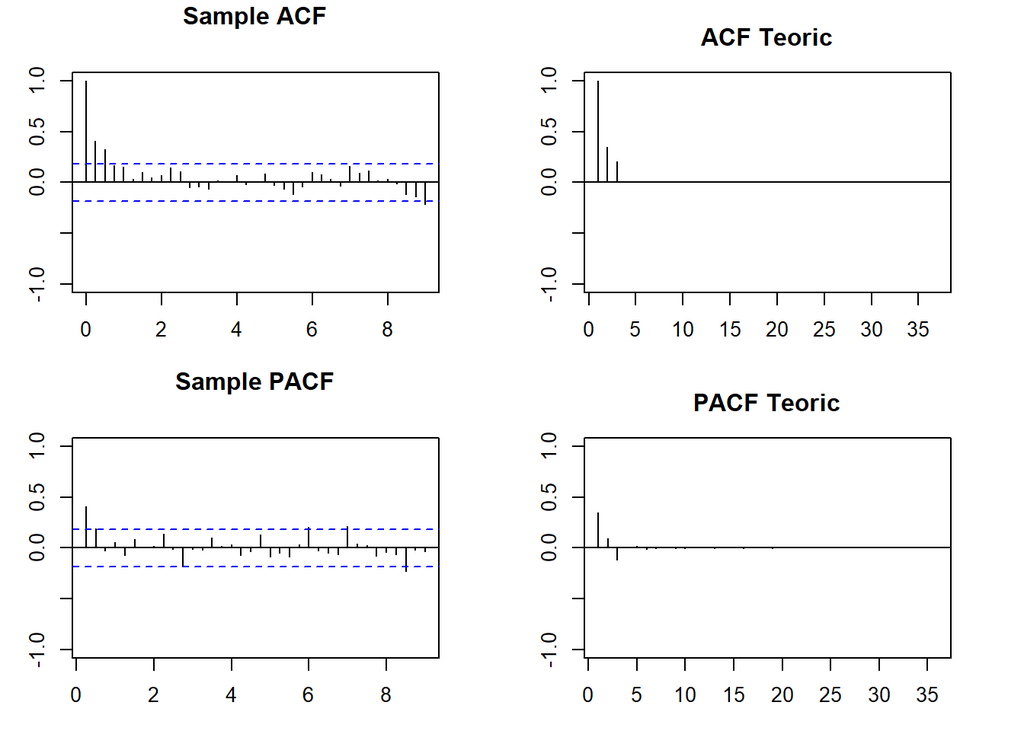

```r
dades=serie
model=mod
validation(model,dades)
```

```r
(mod=arima(serie,order=c(1,0,1)))
```

```
##
## Call:
## arima(x = serie, order = c(1, 0, 1))
##
## Coefficients:
##          ar1      ma1  intercept
##       0.6942  -0.3460     2.4620
## s.e.  0.1368   0.1775     0.4318
##
## sigma^2 estimated as 4.706:  log likelihood = -245.78,  aic = 499.56
```

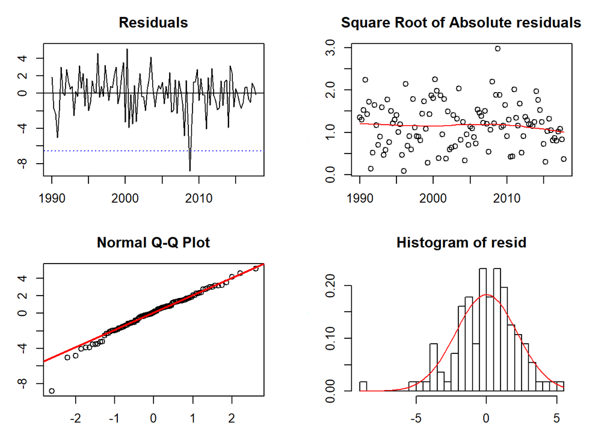

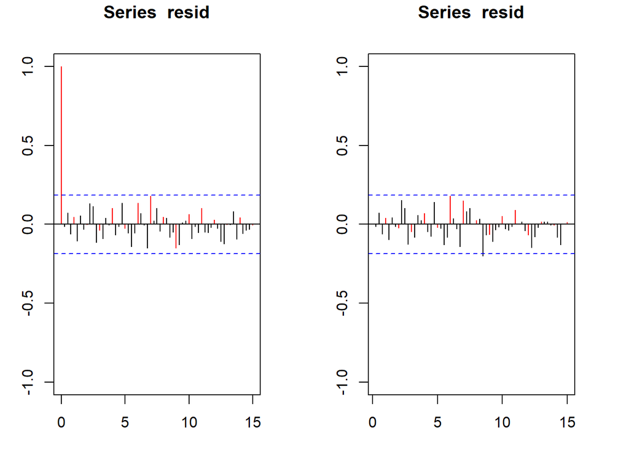

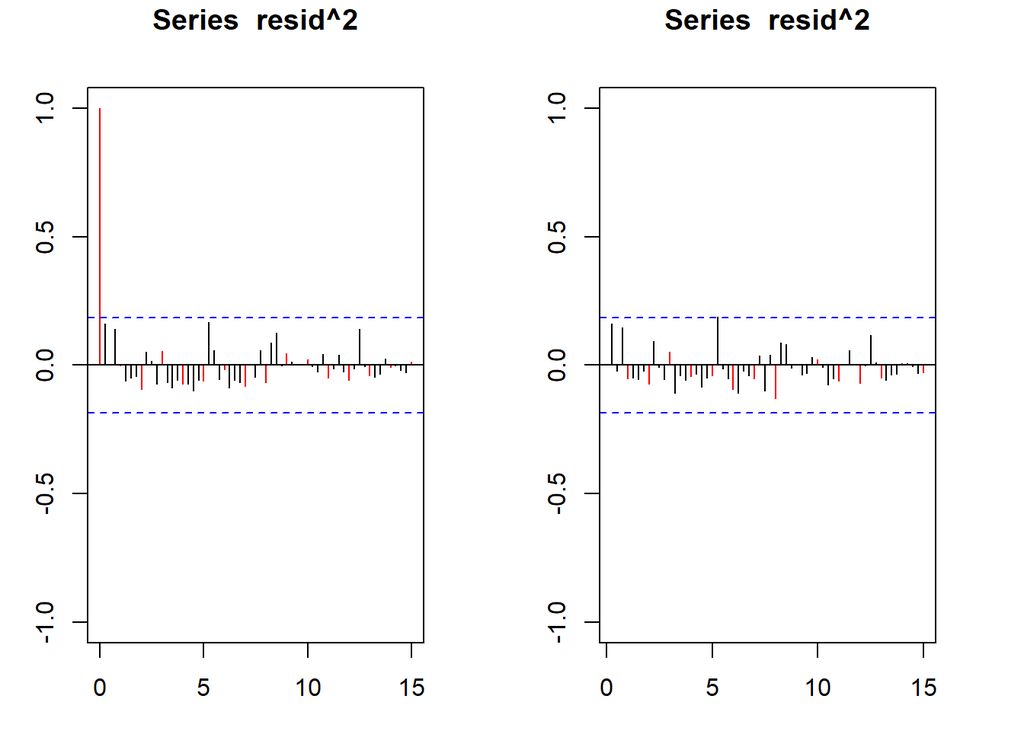

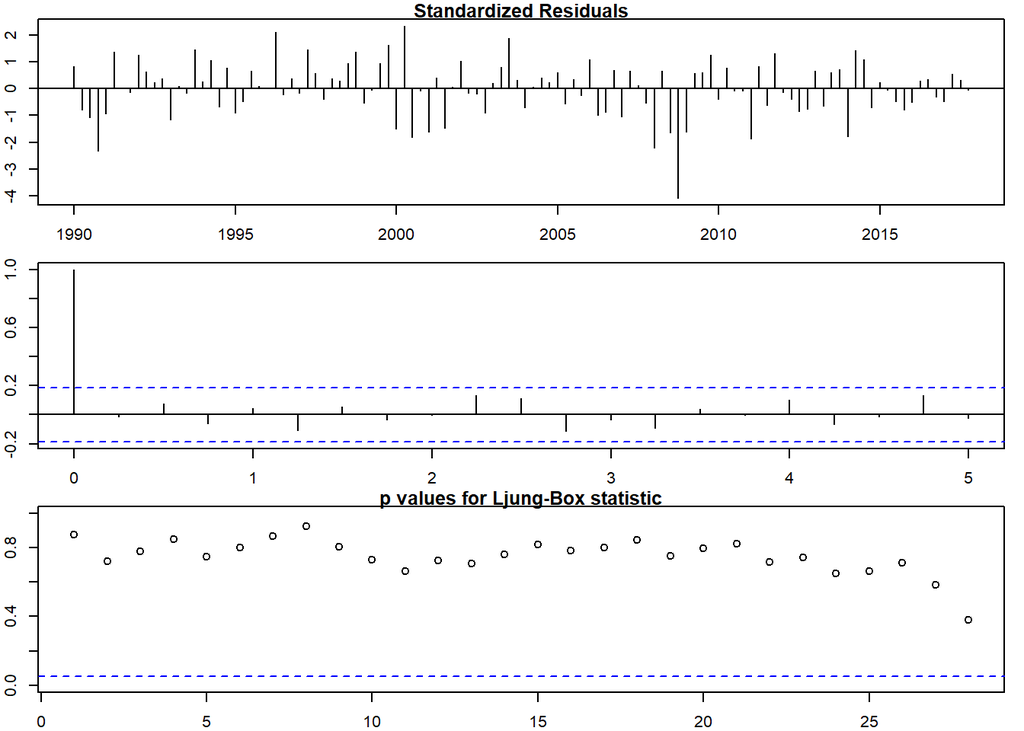

```
##
## --------------------------------------------------------------------
##
## Call:
## arima(x = serie, order = c(1, 0, 1))
##
## Coefficients:
##          ar1      ma1  intercept
##       0.6942  -0.3460     2.4620
## s.e.  0.1368   0.1775     0.4318
##
## sigma^2 estimated as 4.706:  log likelihood = -245.78,  aic = 499.56
##
## Modul of AR Characteristic polynomial Roots:  1.440474
##
## Modul of MA Characteristic polynomial Roots:  2.890053
##
## Psi-weights (MA(inf))
##
## --------------------
##        psi 1        psi 2        psi 3        psi 4        psi 5
## 0.3482014114 0.2417269407 0.1678106749 0.1164968313 0.0808739474
##        psi 6        psi 7        psi 8        psi 9       psi 10
## 0.0561439766 0.0389760387 0.0270577841 0.0187839427 0.0130401109
##       psi 11       psi 12       psi 13       psi 14       psi 15
## 0.0090526517 0.0062844944 0.0043627956 0.0030287219 0.0021025868
##       psi 16       psi 17       psi 18       psi 19       psi 20
## 0.0014596491 0.0010133115 0.0007034569 0.0004883510 0.0003390210
##
## Pi-weights (AR(inf))
##
## --------------------
##         pi 1         pi 2         pi 3         pi 4         pi 5
## 3.482014e-01 1.204827e-01 4.168876e-02 1.442491e-02 4.991228e-03
##         pi 6         pi 7         pi 8         pi 9        pi 10
## 1.727037e-03 5.975798e-04 2.067712e-04 7.154583e-05 2.475589e-05
##        pi 11        pi 12        pi 13        pi 14        pi 15
## 8.565896e-06 2.963924e-06 1.025560e-06 3.548587e-07 1.227862e-07
##        pi 16        pi 17        pi 18        pi 19        pi 20
## 4.248582e-08 1.470071e-08 5.086657e-09 1.760057e-09 6.090050e-10
##
##  Shapiro-Wilk normality test
##
## data:  resid(mod)
## W = 0.97365, p-value = 0.02579
```

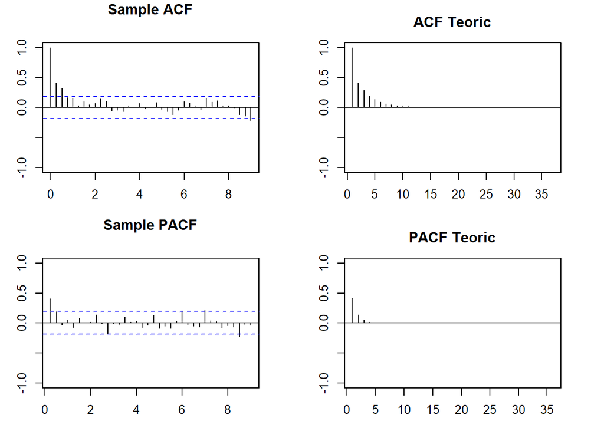

```r
dades=serie
model=mod
validation(model,dades)
```